# R Notebook

#R BASICS

**AUTHOR: EDNA**

**COURSE: BSC. ACTUARIAL SCIENCE**

**EMAIL: jeiedna@gmail.com**

# Starting and quiting R

In Microsoft Windows, the R installer will have created a Start Menu item and an icon for R on your desktop. Double clicking on the R icon starts the program. The first thing that will happen is that R will open the console(into which the user can type commands), other systems may install an icon to click, or may require you to type “R” at a command prompt.

The greater-than sign (>) is the prompt symbol. When this appears, you can begin typing commands.

To quit R you will use the function q()

```r
q()
```

Commands are executed by highlighting them and hitting Ctrl-R (which stands for “run”)

# BASIC COMPUTATIONS USING R

For example, R can be used as a calculator. We can type simple arithmetical expressions at the > prompt:

```r
5+49
```

```
[1] 54
```

The [1] indicates that this is the first (and in this case only) result from the command. Other commands return multiple values, and each line of results will be labeled to aid the user in deciphering the output. For example, the sequence of integers from 1 to 20 may be displayed as follows:

```r
1:20
```

```
 [1]  1  2  3  4  5  6  7  8  9 10 11 12 13 14 15 16 17 18 19 20
```

```r
26%%5
```

```
[1] 1
```

and the integer part of a fraction as

```r
26%/%5
```

```
[1] 5
```

## Comments

Everything following a # sign is assumed to be a Comments and is ignored by R. Each line that begins with a pound sign (#) in the R console is designated as a comment.

### OBJECTS and VARIABLES

Our main concern is how do we define variables and objects? What are variables?

Variables defined at the console have global scope, meaning they are visible in any user-defined function. Variables defined in a function are visible in the function, and in functions defined within it. Using local variables rather than globals helps tremendously in programming, because while you are writing the function, you don’t need to worry about some other part of the program changing the values of your variables. You can predict their values from the code you write, and be sure that once you get it correct, you can trust it.

For example:

```r
age=20 #the student's age is 20 where the value is 20 and the variable is age.
age
```

```
[1] 20
```

We assign value to variables.

In R, we define variables as follows: principal to hold the value of P, and intRate to hold the interest rate, and n to hold the number of payments. We will assign the resulting payment value to an object called payment.

Of course, we need some numerical values to work with, so we will suppose that the loan amount is $1500, the interest rate is 1% and the number of payments is 10. Below is the R code for the annuity function;

```r
intRate <- 0.01
n <- 10
principal <- 1500
payment <- principal * intRate / (1 - (1 + intRate)^(-n))
payment
```

```
[1] 158.3731
```

Note: R does not print anything when we make the assignment. Regardless, the objects were defined successfully. Had you made a mistake, you would have received an error message.

To see the value stored in payment above you can call the variable name as above or a more explicit ay to ask R to show the value stored under variable payment is to use the print() function like this:

```r
print(payment)
```

```
[1] 158.3731
```

To view all the variables in R use ls(){ell ess}

```r
ls()
```

[output not shown]

An alternative is using objects() as illustrated below:

```r
objects()
```

[output not shown]

#### SOME OF THE RULES IN ASSIGNING VARIABLE NAMES IN R ARE:

1. Variable names have to start with a letter.
2. They can’t contain spaces.
3. They should not be variables that are predefined in R.

A nice convention to follow is to use meaningful words that describe what is stored, use only lower case and use underscore as a substitute for spaces. Kindly check out Hadley Wickham’s style guide.

R also has “packages,” which are collections of functions and data. Normally packages have their own scope (known as their “namespace”), but the details of namespaces (and of packages without namespaces) are beyond the scope of this text.

**Data Types**

Variables in R can be of different types. For example, we need to distinguish numbers from character strings and tables from simple lists of nubers. The function class helps us determine what type of object we have:

```r
a=2
class(a)
```

```
[1] "numeric"
```

###### Data frames

Up to now, the variables we have defined are just one number. This is not very useful for storing data. The most common way of storing a dataset in R is in a data frame. Conceptually, we can think of a data frame as a table with rows representing observations and the different variables reported for each observation defining the columns. Data frames are particularly useful for datasets because we can combine different data types into one object.

A large proportion of data analysis challenges start with data stored in a data frame. For example, we stored the data for our motivating example in a data frame. You can access this dataset by loading the dslabs library and loading the murders dataset using the data function:

```r
library(dslabs)
data("murders")
```

To see that this is in fact a data frame, we type:

```r
class(murders)
```

```
[1] "data.frame"
```

# Examining an object

```r
str(murders)
```

```
'data.frame':   51 obs. of  5 variables:
 $ state     : chr  "Alabama" "Alaska" "Arizona" "Arkansas" ...
 $ abb       : chr  "AL" "AK" "AZ" "AR" ...
 $ region    : Factor w/ 4 levels "Northeast","South",..: 2 4 4 2 4 4 1 2 2 2 ...
 $ population: num  4779736 710231 6392017 2915918 37253956 ...
 $ total     : num  135 19 232 93 1257 ...
```

```r
head(murders)
```

|  | state | abb | region | population | total |
| --- | --- | --- | --- | --- | --- |
| 1 | Alabama | AL | South | 4779736 | 135 |
| 2 | Alaska | AK | West | 710231 | 19 |
| 3 | Arizona | AZ | West | 6392017 | 232 |
| 4 | Arkansas | AR | South | 2915918 | 93 |
| 5 | California | CA | West | 37253956 | 1257 |
| 6 | Colorado | CO | West | 5029196 | 65 |

The function str is useful for finding out more about the structure of an object.This tells us much more about the object.

# The accessor: $

For our analysis, we will need to access the different variables represented by columns included in this data frame. To do this, we use the accessor operator $ in the following way:

```r
murders$population
```

```
 [1]  4779736   710231  6392017  2915918 37253956  5029196
 [7]  3574097   897934   601723 19687653  9920000  1360301
[13]  1567582 12830632  6483802  3046355  2853118  4339367
[19]  4533372  1328361  5773552  6547629  9883640  5303925
[25]  2967297  5988927   989415  1826341  2700551  1316470
[31]  8791894  2059179 19378102  9535483   672591 11536504
[37]  3751351  3831074 12702379  1052567  4625364   814180
[43]  6346105 25145561  2763885   625741  8001024  6724540
[49]  1852994  5686986   563626
```

But how did we know to use population? Previously, by applying the function str to the object murders, we revealed the names for each of the five variables stored in this table. We can quickly access the variable names using:

```r
names(murders)
```

```
[1] "state"      "abb"        "region"     "population"
[5] "total"
```

# VECTORS: NUMERICS, CHARACTERS AND LOGICAL

A single number is a vector of length 1. We use the term vectors to refer to objects with several entries. In a data frame, each column is a vector. The function length tells you how many entries are in the vector:

```r
length(murders)
```

```
[1] 5
```

# Creating vectors

We can create vectors using the function c, which stands for concatenate. We use c to concatenate entries in the following way:

```r
codes <- c(380, 124, 818)
codes
```

```
[1] 380 124 818
```

**Subsetting**

We use square brackets to access specific elements of a vector. For the vector codes we defined above, we can access the second element using:

```r
codes[2]
```

[output not shown]

You can get more than one entry by using a multi-entry vector as an index:

```r
codes[c(1,3)]
codes[1:2]
```

[output not shown]

A numeric vector is a list of numbers. The c()function is used to collect things together into a vector. We can type

```r
 c(0, 7, 8)
```

```
[1] 0 7 8
```

```r
#Again, we can assign this to a named object:
  X=c(0, 7, 8);X
```

```
[1] 0 7 8
```

The : symbol can be used to create sequences of increasing (or decreasing) values. For example:

```r
numbers5to20 <- 5:20
numbers5to20
```

```
 [1]  5  6  7  8  9 10 11 12 13 14 15 16 17 18 19 20
```

```r
#alternatively, we can use seq()
values1to20<- seq(1:20)
values1to20
```

```
 [1]  1  2  3  4  5  6  7  8  9 10 11 12 13 14 15 16 17 18 19 20
```

We can also create character vectors. We use the quotes to denote that the entries are characters rather than variable names.

```r
country <- c("italy", "canada", "egypt")
country
```

```
[1] "italy"  "canada" "egypt"
```

In R you can also use single quotes:

```r
country <- c('italy', 'canada', 'egypt')
country
```

```
[1] "italy"  "canada" "egypt"
```

**Not availables (NA)**

When a function tries to coerce one type to another and encounters an impossible case, it usually gives us a warning and turns the entry into a special value called an NA for “not available”. For example:

```r
x <- c("1", "b", "3")
as.numeric(x)
```

[output not shown]

R does not have any guesses for what number you want when you type b, so it does not try.

As a data scientist you will encounter the NAs often as they are generally used for missing data, a common problem in real-world datasets.

**Sequences**

Another useful function for creating vectors generates sequences:

```r
seq(1, 10)
```

```
 [1]  1  2  3  4  5  6  7  8  9 10
```

The first argument defines the start, and the second defines the end which is included. The default is to go up in increments of 1, but a third argument lets us tell it how much to jump by:

```r
seq(1, 10, 2)
```

```
[1] 1 3 5 7 9
```

If we want consecutive integers, we can use the following shorthand:

```r
1:10
```

```
 [1]  1  2  3  4  5  6  7  8  9 10
```

When we use these functions, R produces integers, not numerics, because they are typically used to index something:

```r
class(1:10)
```

```
[1] "integer"
```

However, if we create a sequence including non-integers, the class changes:

```r
class(seq(1, 10, 0.5))
```

```
[1] "numeric"
```

Another important type of vectors are the logical vectors. These must either be true or false. For example:

```r
eg=3==1
eg
```

```
[1] FALSE
```

```r
class(eg)
```

```
[1] "logical"
```

The == is a relational operator asking if 3 is equal to 1. In R when you use one = sign we assign a varible and when you use == we are testing for equality.

# Coercison or concatenation

Vectors can be joined together (i.e. concatenated) with the c function. For example, note what happens when we type

```r
 c(numbers5to20, X)
```

```
 [1]  5  6  7  8  9 10 11 12 13 14 15 16 17 18 19 20  0  7  8
```

```r
#Here is another example of the use of the c()function:

some.numbers <- c(2, 3, 5, 7, 11, 13, 17, 19, 23, 29, 31, 37, 41,
43, 47, 59, 67, 71, 73, 79, 83, 89, 97, 103, 107, 109, 113, 119)
some.numbers
```

```
 [1]   2   3   5   7  11  13  17  19  23  29  31  37  41  43  47
[16]  59  67  71  73  79  83  89  97 103 107 109 113 119
```

# FACTORS AND LISTS

In the murders dataset, we might expect the region to also be a character vector. However, it is not:

```r
class(murders$region)
```

```
[1] "factor"
```

It is a factor. Factors are useful for storing categorical data. We can see that there are only 4 regions by using the levels function:

```r
levels(murders$region)
```

```
[1] "Northeast"     "South"         "North Central"
[4] "West"
```

```r
region <- murders$region
value <- murders$total
region <- reorder(region, value, FUN = sum)
levels(region)
```

```
[1] "Northeast"     "North Central" "West"
[4] "South"
```

Data frames are a special case of lists.

###### IMPORTING DATA INTO R

We have been using data sets already stored as R objects. A data scientist will rarely have such luck and will have to import data into R from either a file, a database, or other sources. Currently, one of the most common ways of storing and sharing data for analysis is through electronic spreadsheets. A spreadsheet stores data in rows and columns. It is basically a file version of a data frame. When saving such a table to a computer file, one needs a way to define when a new row or column ends and the other begins. This in turn defines the cells in which single values are stored.

R offers options to import many files. For example, this is how to import a CSV into R.

```r
cbkdata.dat=read.csv("C:/Users/Mwenda/Desktop/PROJECT 2017.18/cbkdata.csv")
cbkdata
```

| Date | Euro | S.Franc | SA.Rand | STG.Pound | US.Dollar |
| --- | --- | --- | --- | --- | --- |
| 2/11/2004 | 103.3680 | 67.5105 | 13.2639 | 148.818 | 81.2078 |
| 3/11/2004 | 102.8440 | 67.0516 | 13.1779 | 148.995 | 81.2117 |
| 4/11/2004 | 104.0250 | 67.9806 | 13.2981 | 149.939 | 81.1472 |
| 5/11/2004 | 104.4850 | 68.3714 | 13.2567 | 149.643 | 81.1306 |
| 8/11/2004 | 105.2780 | 68.8970 | 13.2014 | 150.563 | 81.1444 |
| 9/11/2004 | 104.7940 | 68.6199 | 13.0608 | 150.412 | 81.1500 |
| 10/11/2004 | 104.6480 | 68.5343 | 13.0294 | 150.544 | 81.1439 |
| 11/11/2004 | 104.3940 | 68.5647 | 13.0093 | 149.636 | 81.0689 |
| 12/11/2004 | 104.7670 | 68.9336 | 13.0619 | 149.940 | 81.1139 |
| 16/11/2004 | 104.7670 | 68.9336 | 13.0619 | 149.940 | 81.1139 |

[output cut: 990 more lines]

The best way to import a data from excel is to save this as in CSV format, below is the procedure:

```
Open your Excel data
Go to File > Save As or press Ctrl+Shift+S
Name this with anything you want, say Data. Then before clicking Save, make sure to change the File Format to Comma Delimited Text and better set the directory to My Documents folder, for Windows.
When saved, this file will have a name Data.csv.
```

Now open R, and run the following

```r
MyRData <- read.csv("cbkdata", header = TRUE)
```

**MATRICES**

Matrices are another type of object that are common in R. Matrices are similar to data frames in that they are two-dimensional: they have rows and columns. However, like numeric, character and logical vectors, entries in matrices have to be all the same type. For this reason data frames are much more useful for storing data, since we can have characters, factors and numbers in them.

We can define a matrix using the matrix function. We need to specify the number of rows and columns.

```r
mat=matrix(1:12,4,3) #by row is set at default False
mat
```

```
     [,1] [,2] [,3]
[1,]    1    5    9
[2,]    2    6   10
[3,]    3    7   11
[4,]    4    8   12
```

```r
mat2= matrix(1:12, 4,3,byrow = T);mat2
```

```
     [,1] [,2] [,3]
[1,]    1    2    3
[2,]    4    5    6
[3,]    7    8    9
[4,]   10   11   12
```

You can access specific entries in a matrix using square brackets ([). If you want the second row, third column, you use:

```r
mat[2, 3]
```

```
[1] 10
```

If you want the entire second row, you leave the column spot empty:

```r
mat[2, ]
```

```
[1]  2  6 10
```

Notice that this returns a vector, not a matrix.

Similarly, if you want the entire third column, you leave the row spot empty:

```r
mat[, 3]
```

```
[1]  9 10 11 12
```

This is also a vector, not a matrix.

You can access more than one column or more than one row if you like. This will give you a new matrix.

```r
mat[, 2:3]
```

```
     [,1] [,2]
[1,]    5    9
[2,]    6   10
[3,]    7   11
[4,]    8   12
```

You can subset both rows and columns:

```r
mat[1:2, 2:3]
```

```
     [,1] [,2]
[1,]    5    9
[2,]    6   10
```

We can convert matrices into data frames using the function as.data.frame:

```r
as.data.frame(mat)
```

| V1 | V2 | V3 |
| --- | --- | --- |
| 1 | 5 | 9 |
| 2 | 6 | 10 |
| 3 | 7 | 11 |
| 4 | 8 | 12 |

You can also use single square brackets ([) to access rows and columns of a data frame:

```r
data("murders")
murders[25, 1]
```

```
[1] "Mississippi"
```

```r
murders[2:3, ]
```

|  | state | abb | region | population | total |
| --- | --- | --- | --- | --- | --- |
| 2 | Alaska | AK | West | 710231 | 19 |
| 3 | Arizona | AZ | West | 6392017 | 232 |

## Sorting

Now that we have mastered some basic R knowledge, let’s try to gain some insights into the safety of different states in the context of gun murders.

**Sort**

Say we want to rank the states from least to most gun murders. The function sort sorts a vector in increasing order. We can therefore see the largest number of gun murders by typing:

```r
library(dslabs)
data(murders)
sort(murders$total)
```

```
 [1]    2    4    5    5    7    8   11   12   12   16   19   21
[13]   22   27   32   36   38   53   63   65   67   84   93   93
[25]   97   97   99  111  116  118  120  135  142  207  219  232
[37]  246  250  286  293  310  321  351  364  376  413  457  517
[49]  669  805 1257
```

**Order**

The function order is closer to what we want. It takes a vector as input and returns the vector of indexes that sorts the input vector. This may sound confusing so let’s look at a simple example. We can create a vector and sort it:

```r
x <- c(31, 4, 15, 92, 65)
sort(x)
```

```
[1]  4 15 31 65 92
```

Rather than sort the input vector, the function order returns the index that sorts input vector:

```r
index <- order(x)
x[index]
```

```
[1]  4 15 31 65 92
```

This is the same output as that returned by sort(x). If we look at this index, we see why it works:

```r
x
```

```
[1] 31  4 15 92 65
```

```r
order(x)
```

```
[1] 2 3 1 5 4
```

The second entry of x is the smallest, so order(x) starts with 2. The next smallest is the third entry, so the second entry is 3 and so on.

One might wonder… How does this help us order the states by murders? First, remember that the entries of vectors you access with $ follow the same order as the rows in the table. For example, these two vectors containing state names and abbreviations respectively are matched by their order:

```r
murders$state[1:10]
```

```
 [1] "Alabama"              "Alaska"
 [3] "Arizona"              "Arkansas"
 [5] "California"           "Colorado"
 [7] "Connecticut"          "Delaware"
 [9] "District of Columbia" "Florida"
```

```r
murders$abb[1:10]
```

```
 [1] "AL" "AK" "AZ" "AR" "CA" "CO" "CT" "DE" "DC" "FL"
```

This means we can order the state names by their total murders. We first obtain the index that orders the vectors according to murder totals and then index the state names vector:

```r
ind <- order(murders$total)
murders$abb[ind]
```

```
 [1] "VT" "ND" "NH" "WY" "HI" "SD" "ME" "ID" "MT" "RI" "AK" "IA"
[13] "UT" "WV" "NE" "OR" "DE" "MN" "KS" "CO" "NM" "NV" "AR" "WA"
[25] "CT" "WI" "DC" "OK" "KY" "MA" "MS" "AL" "IN" "SC" "TN" "AZ"
[37] "NJ" "VA" "NC" "MD" "OH" "MO" "LA" "IL" "GA" "MI" "PA" "NY"
[49] "FL" "TX" "CA"
```

**Rank**

Although not as frequently used as order and sort, the function rank is also related to order and can be useful. For any given vector it returns a vector with the rank of the first entry, second entry, etc., of the input vector. Here is a simple example:

```r
x <- c(31, 4, 15, 92, 65)
rank(x)
```

```
[1] 3 1 2 5 4
```

#### Basic plots

Here we briefly describe some of the functions that are available in a basic R installation.

**PLOT** The plot function can be used to make scatterplots. Here is a plot of total murders versus population.

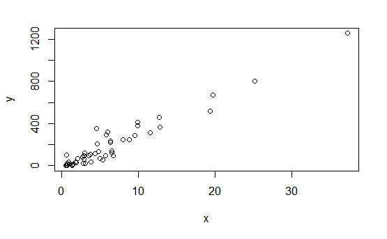

```r
x <- murders$population / 10^6
y <- murders$total
plot(x,y)
```

For a quick plot that avoids accessing variables twice, we can use the with function:

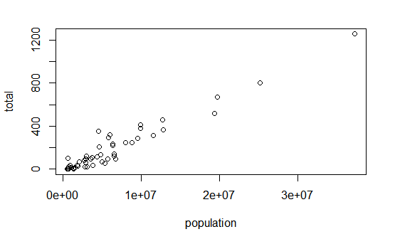

```r
with(murders, plot(population, total))
```

The function with lets us use the murders column names in the plot function. It also works with any data frames and any function.

**Histograms**

```r
x <- with(murders, total / population * 100000)
hist(x)
```

[output not shown]

```r
murders$state[which.max(x)]
```

[output not shown]

##### Boxplot

Boxplots will also be described in the Data Visualization part of the book. They provide a more terse summary than histograms, but they are easier to stack with other boxplots. For example, here we can use them to compare the different regions:

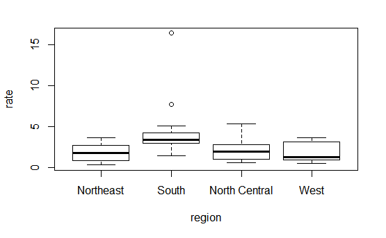

```r
murders$rate <- with(murders, total / population * 100000)
boxplot(rate~region, data = murders)
```

**IMAGE**

The image function displays the values in a matrix using color. Here is a quick example:

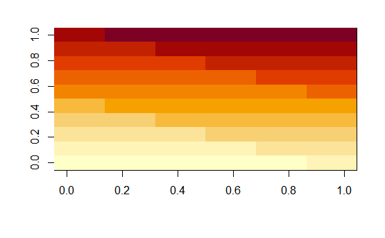

```r
x <- matrix(1:120, 12, 10)
image(x)
```